# Statistical Package for Queueing in R

Angyalka Valcsics, Pearl Armstrong, Shawn Houser

University of Southern Maine

9/14/2021

## Introduction

Queueing theory is the mathematical study of the formation and function of queues. A basic queueing system is a system where entities arrive at a facility requiring some service, they join a line, and wait for service from one or more servers. The results of queueing analysis can be used to offer faster customer service, increase traffic flow, improve order shipments from a warehouse, or to design data networks and call centers. In this first demonstration, we will use the random events of arrivals and service completions from a general distribution to demonstrate the development of a queue over time. We assume the reader has some previous knowledge of queueing networks.

## Measures of System Performance

| Variable | Definition |
| --- | --- |
| $\lambda$ | Average arrival rate |
| $S$ | Random service time |
| $\mu$ | Average service rate |
| $c$ | Number of servers |
| $r = \lambda / \mu$ | Offered load |
| $\rho = \lambda / c \mu$ | Traffic intensity or utilization |
| $T, T_{q}$ | Random time a customer spends in the system / queue |
| $W, W_{q}$ | Average time a customer spends in the system / queue |
| $N, N_{q}$ | Random number of customers in the system / queue |
| $L, L_{q}$ | Average number of customers in the system / queue |

## Notation and relationships for G/G/1 queue

In event-oriented bookkeeping, the system state is only updated when events occur. Either when customers/jobs arrive or depart. Suppose we observe a system, recording the times of arrival and service for each entity. An alternative to recording arrival times is to record the time between arrivals. With this information we can calculate measures of performance (see table above) and find other bookkeeping results such as:

| Variable | Definition | Sample relationship |
| --- | --- | --- |
| $A^{(n)}$ | Arrival time of cust. $n$ |  |
| $S^{(n)}$ | Service time of cust. $n$ |  |
| $T^{(n)}$ | Inter. time cust. $n$ and $n+1$ | $T^{(n)} = A^{(n+1)} - A^{(n)}$ |
| $U^{(n)}$ | Time cust. $n$ starts service | $U^{(n+1)} = max\{D^{(n)}, A^{(n+1)}\}$ |
| $D^{(n)}$ | Departure time of cust. $n$ | $D^{(n)} = U^{(n)} + S^{(n)}$ |
| $W_{q}^{(n)}$ | Time in queue of cust. $n$ | $W_{q}^{(n)} = U^{(n)} - A^{(n)}$ |
| $W^{(n)}$ | Time in system of cust. $n$ | $W^{(n)} = W_{q}^{(n)} + S^{(n)}$ |

The analysis is obtained under the assumption of a single server with FCFS discipline. No assumptions are required on the probability laws for the interarrival times or service times.

The gg1.summary() function takes three inputs. First an input of either the arrival times or the interarrival times, the service times, and a Boolean–set interarrival = TRUE if the first input is interarrival times. The function outputs a data frame with the bookkeeping values for each entity and a data frame which holds some performance measures.The user can access performance measures by name using the $ operator. Please see the examples that follow.

```r
# Arrival times
arrival <- c(0, 2, 3, 6, 7, 8, 12, 14, 19, 20, 24, 26)
# Service times
service <- c(1, 3, 6, 2, 1, 1, 1, 2, 5, 1, 1, 3)
# Run gg1.summary() on this data
q <- gg1.summary(arrival, service)
# Use gt package for nice tables
library(gt)
# Get bookkeeping results
pt <- q$bookkeeping
pt %>%
   gt() %>%
   tab_header(
      title = md("Event-Oriented Bookkeeping for G/G/1 Queues"))
```

Event-Oriented Bookkeeping for G/G/1 Queues

| customers | arrivals | service_times | interarrival_times | starts_service | departure_times | queue_times | system_times |
| --- | --- | --- | --- | --- | --- | --- | --- |
| 1 | 0 | 1 | 2 | 0 | 1 | 0 | 1 |
| 2 | 2 | 3 | 1 | 2 | 5 | 0 | 3 |
| 3 | 3 | 6 | 3 | 5 | 11 | 2 | 8 |
| 4 | 6 | 2 | 1 | 11 | 13 | 5 | 7 |
| 5 | 7 | 1 | 1 | 13 | 14 | 6 | 7 |
| 6 | 8 | 1 | 4 | 14 | 15 | 6 | 7 |
| 7 | 12 | 1 | 2 | 15 | 16 | 3 | 4 |
| 8 | 14 | 2 | 5 | 16 | 18 | 2 | 4 |
| 9 | 19 | 5 | 1 | 19 | 24 | 0 | 5 |
| 10 | 20 | 1 | 4 | 24 | 25 | 4 | 5 |
| 11 | 24 | 1 | 2 | 25 | 26 | 1 | 2 |
| 12 | 26 | 3 | NA | 26 | 29 | 0 | 3 |

```r
# Get performance results
qt <- q$res
qt %>%
   gt() %>%
   tab_header(
      title = md("Measures of Performance for G/G/1 Queues"))
```

Measures of Performance for G/G/1 Queues

| Definition | Result |
| --- | --- |
| Average arrival rate | 0.4138 |
| Utilization | 0.931 |
| Idle time | 0.069 |
| Average time in system | 4.6667 |
| Average time in queue | 2.4167 |
| Average number in system | 1.931 |
| Average number in queue | 1 |

Now suppose that we only had data on the interarrival times and the service times.

```r
# Interarrival times
inter <- c(1, 9, 6, 4, 7, 9, 5, 8, 4, 10, 6, 12, 6, 8,
           9, 5, 7, 8, 8, 7)
# Service times
serv <- c(3, 7, 9, 9, 10, 4, 8, 5, 5, 3, 6, 3, 5, 4,
          9, 9, 8, 6, 8, 3)
# Run gg1.summary() on this data
q2 <- gg1.summary(inter, serv, interarrival = TRUE)
pt2 <- q2$bookkeeping
pt2 %>%
   gt() %>%
   tab_header(
      title = md("Event-Oriented Bookkeeping for G/G/1 Queues"))
```

Event-Oriented Bookkeeping for G/G/1 Queues

| customers | arrival_times | service_times | interarrival_times | starts_service | departure_times | queue_times | system_times |
| --- | --- | --- | --- | --- | --- | --- | --- |
| 0 | 0 | NA | 1 | NA | NA | NA | NA |
| 1 | 1 | 3 | 9 | 1 | 4 | 0 | 3 |
| 2 | 10 | 7 | 6 | 10 | 17 | 0 | 7 |
| 3 | 16 | 9 | 4 | 17 | 26 | 1 | 10 |
| 4 | 20 | 9 | 7 | 26 | 35 | 6 | 15 |
| 5 | 27 | 10 | 9 | 35 | 45 | 8 | 18 |
| 6 | 36 | 4 | 5 | 45 | 49 | 9 | 13 |
| 7 | 41 | 8 | 8 | 49 | 57 | 8 | 16 |
| 8 | 49 | 5 | 4 | 57 | 62 | 8 | 13 |
| 9 | 53 | 5 | 10 | 62 | 67 | 9 | 14 |
| 10 | 63 | 3 | 6 | 67 | 70 | 4 | 7 |
| 11 | 69 | 6 | 12 | 70 | 76 | 1 | 7 |
| 12 | 81 | 3 | 6 | 81 | 84 | 0 | 3 |
| 13 | 87 | 5 | 8 | 87 | 92 | 0 | 5 |
| 14 | 95 | 4 | 9 | 95 | 99 | 0 | 4 |
| 15 | 104 | 9 | 5 | 104 | 113 | 0 | 9 |
| 16 | 109 | 9 | 7 | 113 | 122 | 4 | 13 |
| 17 | 116 | 8 | 8 | 122 | 130 | 6 | 14 |
| 18 | 124 | 6 | 8 | 130 | 136 | 6 | 12 |
| 19 | 132 | 8 | 7 | 136 | 144 | 4 | 12 |
| 20 | 139 | 3 | NA | 144 | 147 | 5 | 8 |

```r
# Get performance results
qt2 <- q2$res
qt2 %>%
   gt() %>%
   tab_header(
      title = md("Measures of Performance for G/G/1 Queues"))
```

Measures of Performance for G/G/1 Queues

| Definition | Result |
| --- | --- |
| Average arrival rate | 0.1361 |
| Utilization | 0.8435 |
| Idle time | 0.1565 |
| Average time in system | 10.15 |
| Average time in queue | 3.95 |
| Average number in system | 1.381 |
| Average number in queue | 0.5374 |

## The Birth Death Process

Suppose you want to solve the flow balance equation for a birth-death type queue with finite capacity $n$. Given an array of arrival (birth) rates $\lambda = (\lambda_{0}, \lambda_{1}, \cdots)$ and an array of service (death) rates $\mu = (\mu_{1}, \mu_{2}, \cdots)$, the function BD.solve($\lambda$, $\mu$) will return $\{p_n, n \geq 0\}$, the discrete distribution of number of customers in system. Please see the following example with $\lambda = (3, 2, 1)$ and $\mu = (1, 2, 2)$.

```r
mu = c(1, 2, 2)
lambda = c(3, 2, 1)
pn = BD.solve(lambda, mu)
print(pn)
```

```
## [1] 0.1176471 0.3529412 0.3529412 0.1764706
```

Where the first element corresponds to $p_0$, the second to $p_1$, and so on.

## M/M/c Markovian model

```
## [1] "System is stable."
```

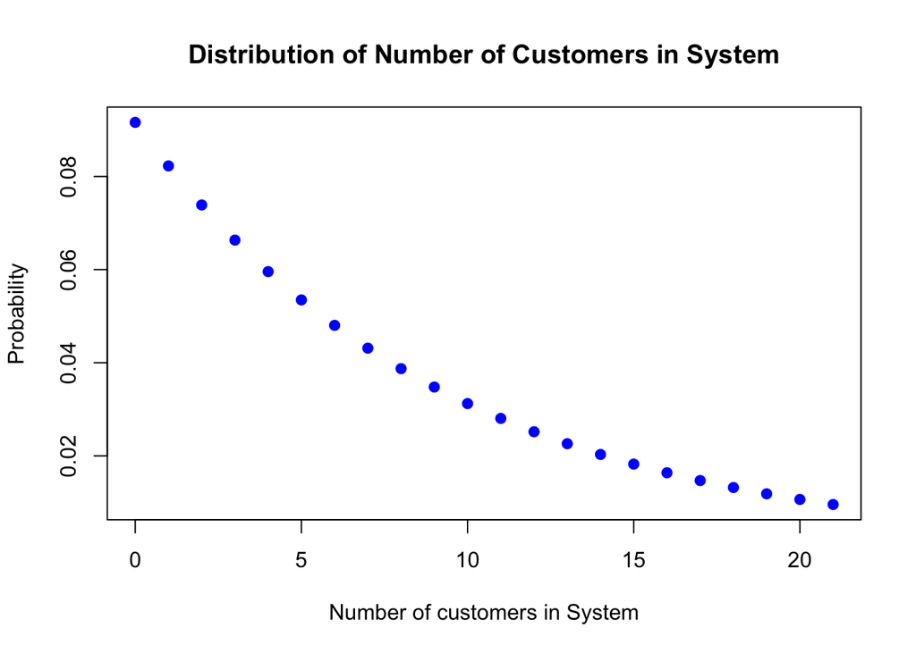

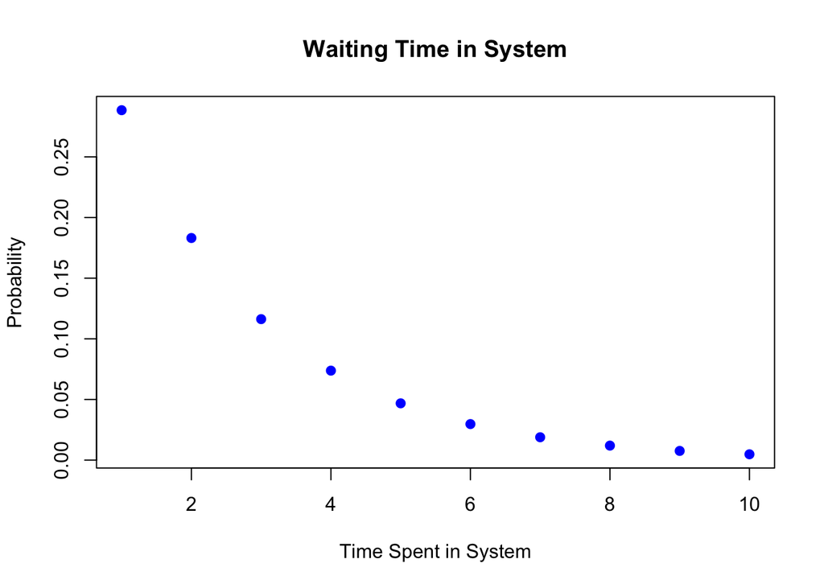

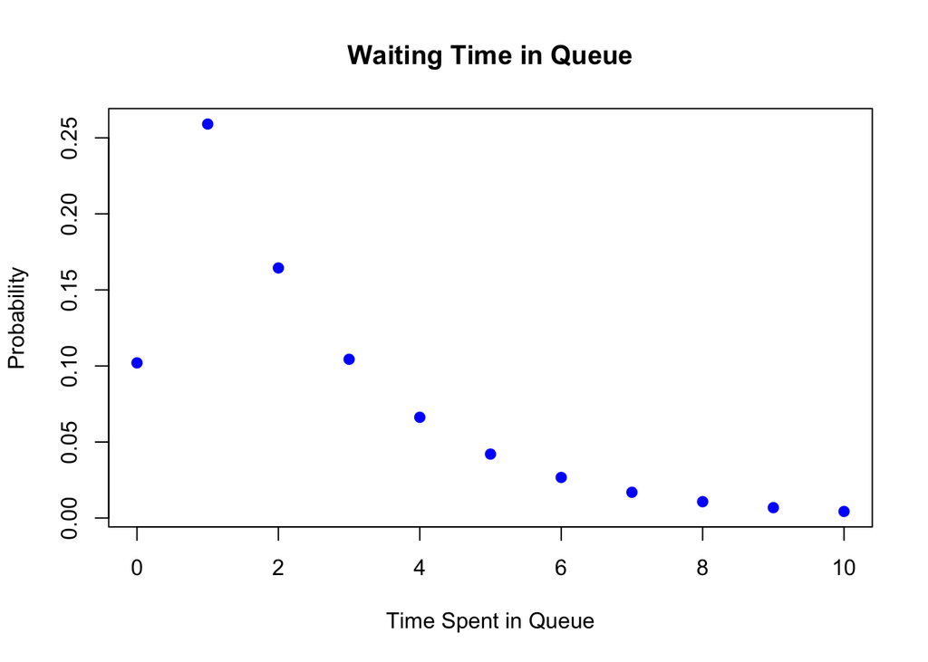

```r
q <- mmc.summary(lambda = 4, mu = 4.4545, c = 1, plot_pn = TRUE,
                 plot_waitQ = TRUE,
                 plot_waitSys = TRUE)
```

```r
library(gt)
qt <- q$res
qt %>%
   gt() %>%
   tab_header(
      title = md("Measures of Performance for M/M/1 Queues"))
```

Measures of Performance for M/M/1 Queues

| Definition | Result |
| --- | --- |
| Average arrival rate | 4 |
| Utilization | 0.898 |
| Idle time | 0.102 |
| Average time in system | 2.2002 |
| Average time in queue | 1.9757 |
| Average number in system | 8.8009 |
| Average number in queue | 7.9029 |

Using the output we can find the probability that there are more than $k$ entities in the system using the formula $P(X \geq k) = \rho^{k}$. Suppose we wanted to find the probability that there are more than $k = 2$ entities in the system.

```r
k = 2
prob_k_system <- (q$rho)^k
print(prob_k_system)
```

```
## [1] 0.8063472
```

Recall that we can also find the following two probabilities.
$$P(T > t) = e^{-\mu (1-\rho)t}$$

```r
mu = 4.4545
t <- 2
pr <- exp(-mu*(1 - q$rho)*t)
print(pr)
```

```
## [1] 0.4029269
```

$$P(T_q > t) = \rho e^{-\mu (1-\rho)t}$$

```r
mu = 4.4545
t <- 2
pr2 <- (q$rho)*exp(-mu*(1 - q$rho)*t)
print(pr2)
```

```
## [1] 0.3618156
```

Moving on, we consider Markovian queueing models with parallel channels: M/M/c/$\infty$/$\infty$ queues.

```
## [1] "System is stable."
```

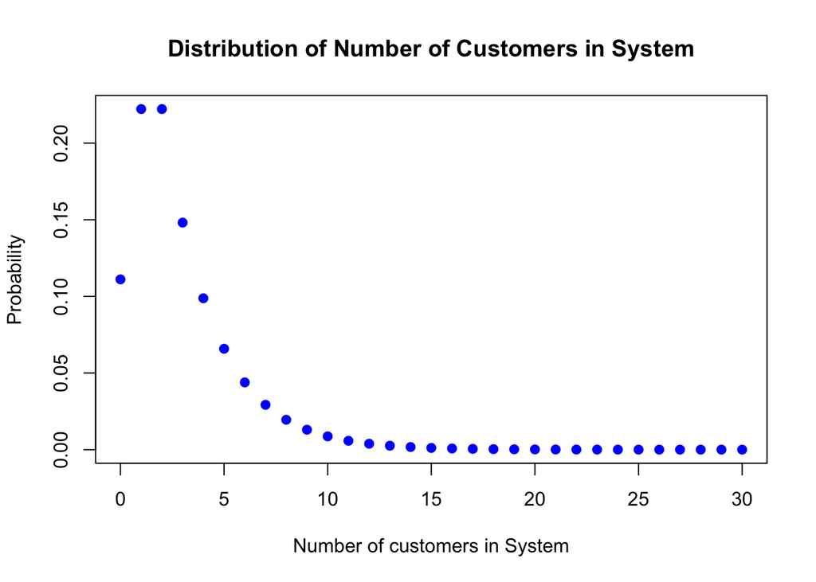

```r
q <- mmc.summary(lambda = 4, mu = 2, c = 3, plot_pn = TRUE)
```

```r
library(gt)
qt <- q$res
qt %>%
   gt() %>%
   tab_header(
      title = md("Measures of Performance for M/M/c Queues"))
```

Measures of Performance for M/M/c Queues

| Definition | Result |
| --- | --- |
| Average arrival rate | 4 |
| Utilization | 0.6667 |
| Idle time | 0.1111 |
| Mean number busy servers | 2 |
| Average time in system | 0.7222 |
| Average time in queue | 0.2222 |
| Average number in system | 2.8889 |
| Average number in queue | 0.8889 |

You may have noticed that we did not plot the probability density functions for waiting times in queue or waiting times in system for the m/m/c queue. Instead we define two functions for m/m/c queues which return the cumulative probabilities $P\{T \geq t\}$ and $P\{T_q \geq t\}$.